# Beadando

2024-12-08

## EU Student Mobility

The selected topic is **EU Student Mobility** analysis. The source of data is coming from *https://raw.githubusercontent.com/rfordatascience/tidytuesday/refs/heads/main/data/2022/2022-03-08/erasmus.csv* The dataset contains data about Erasmus students moving two different schools. The data contains details about the students and about the institutes and locations.

### Raw Data

In this section I read the data from the raw CSV format, with skipping the possible empty lines, because these ones are irrelevant for my project. I print out the first few lines of the data to see how it looks like and also print out the name of all the columns, which is useful to know for later analysis.

```r
library(knitr)
library(tidyverse)
dataSourceInput <- readr::read_csv("https://raw.githubusercontent.com/rfordatascience/tidytuesday/refs/heads/main/data/2022/2022-03-08/erasmus.csv", show_col_types = FALSE, skip_empty_rows = TRUE)
kable(head(dataSourceInput)) # Show the first few lines
```

| project_reference | academic_year | mobility_start_month | mobility_end_month | mobility_duration | activity_mob | field_of_education | participant_nationality | education_level | participant_gender | participant_profile | special_needs | fewer_opportunities | group_leader | participant_age | sending_country_code | sending_city | sending_organization | sending_organisation_erasmus_code | receiving_country_code | receiving_city | receiving_organization | receiving_organisation_erasmus_code | participants |
| --- | --- | --- | --- | --- | --- | --- | --- | --- | --- | --- | --- | --- | --- | --- | --- | --- | --- | --- | --- | --- | --- | --- | --- |
| 2014-1-AT02-KA347-000139 | 2014-2015 | 2014-11 | 2014-11 | 1 | National youth meetings | ? Unknown ? | AT | ??? - ? Unknown ? | Female | Learner | No | Yes | No | 13 | AT | Dornbirn | bOJA - Bundesweites Netzwerk Offene Jugendarbeit | - | AT | Dornbirn | bOJA - Bundesweites Netzwerk Offene Jugendarbeit | - | 2 |
| 2014-1-AT02-KA347-000139 | 2014-2015 | 2014-11 | 2014-11 | 1 | National youth meetings | ? Unknown ? | AT | ??? - ? Unknown ? | Female | Learner | No | Yes | No | 14 | AT | Dornbirn | bOJA - Bundesweites Netzwerk Offene Jugendarbeit | - | AT | Dornbirn | bOJA - Bundesweites Netzwerk Offene Jugendarbeit | - | 3 |
| 2014-1-AT02-KA347-000139 | 2014-2015 | 2014-11 | 2014-11 | 1 | National youth meetings | ? Unknown ? | AT | ??? - ? Unknown ? | Female | Learner | No | Yes | No | 15 | AT | Dornbirn | bOJA - Bundesweites Netzwerk Offene Jugendarbeit | - | AT | Dornbirn | bOJA - Bundesweites Netzwerk Offene Jugendarbeit | - | 3 |
| 2014-1-AT02-KA347-000139 | 2014-2015 | 2014-11 | 2014-11 | 1 | National youth meetings | ? Unknown ? | AT | ??? - ? Unknown ? | Male | Learner | No | Yes | No | 14 | AT | Dornbirn | bOJA - Bundesweites Netzwerk Offene Jugendarbeit | - | AT | Dornbirn | bOJA - Bundesweites Netzwerk Offene Jugendarbeit | - | 4 |
| 2014-1-AT02-KA347-000139 | 2014-2015 | 2014-11 | 2014-11 | 1 | National youth meetings | ? Unknown ? | AT | ??? - ? Unknown ? | Male | Learner | No | Yes | No | 15 | AT | Dornbirn | bOJA - Bundesweites Netzwerk Offene Jugendarbeit | - | AT | Dornbirn | bOJA - Bundesweites Netzwerk Offene Jugendarbeit | - | 2 |
| 2014-1-AT02-KA347-000139 | 2014-2015 | 2014-12 | 2014-12 | 1 | National youth meetings | ? Unknown ? | AT | ??? - ? Unknown ? | Male | Learner | No | No | No | 15 | AT | Wien | bOJA - Bundesweites Netzwerk Offene Jugendarbeit | - | AT | Wien | bOJA - Bundesweites Netzwerk Offene Jugendarbeit | - | 2 |

```r
colnames(dataSourceInput) # Show all the column names
```

```
##  [1] "project_reference"                   "academic_year"
##  [3] "mobility_start_month"                "mobility_end_month"
##  [5] "mobility_duration"                   "activity_mob"
##  [7] "field_of_education"                  "participant_nationality"
##  [9] "education_level"                     "participant_gender"
## [11] "participant_profile"                 "special_needs"
## [13] "fewer_opportunities"                 "group_leader"
## [15] "participant_age"                     "sending_country_code"
## [17] "sending_city"                        "sending_organization"
## [19] "sending_organisation_erasmus_code"   "receiving_country_code"
## [21] "receiving_city"                      "receiving_organization"
## [23] "receiving_organisation_erasmus_code" "participants"
```

#### Data Dictionary

This chapter shows all the fields a short explanation. This documentation is coming from the source of the data.

| variable | class | description |
| --- | --- | --- |
| project_reference | character | Project reference is an aggregation of several information (YYYY-X-AAAA-KKKKK-NNNNN) where YYYY represent year, X represents the round within the call year, AAAA represents the National Agency managin… |
| academic_year | character | Only relevant for higher education (KA103, KA107) - Year-Month (YYYY-MM) |
| mobility_start_month | character | Year-Month (YYYY-MM) |
| mobility_end_month | character | Year-Month (YYYY-MM) |
| mobility_duration | double | Exact duration of the mobility in calendar days (date2-date1) |
| activity_mob | character | . |
| field_of_education | character | Participant field of education |
| participant_nationality | character | Code (DE, FR, BE, …..) |
| education_level | character | Included where relevant |
| participant_gender | character | Male/Female/Undefined |
| participant_profile | character | Staff or learner, training can be retrieved from activity field |
| special_needs | character | Yes/no |
| fewer_opportunities | character | Yes/no |
| group_leader | character | Yes/no |
| participant_age | double | Age at start of mobility in years |
| sending_country_code | character | Code (DE, FR, BE, …..) |
| sending_city | character | City of sending organisation |
| sending_organization | character | Name of organisation |
| sending_organisation_erasmus_code | character | Organisation Erasmus code |
| receiving_country_code | character | Code (DE, FR, BE, …..) |
| receiving_city | character | City of receiving organisationn |
| receiving_organization | character | Name of organisation |
| receiving_organisation_erasmus_code | character | Organisation Erasmus code |
| participants | double | Total number of participants |

### Handle missing values

I’m using summary function to check that each datafield value and to check if it contains NA’s or not.

```r
summary(dataSourceInput)
```

```
##  project_reference  academic_year      mobility_start_month mobility_end_month
##  Length:164635      Length:164635      Length:164635        Length:164635
##  Class :character   Class :character   Class :character     Class :character
##  Mode  :character   Mode  :character   Mode  :character     Mode  :character
##
##
##
##  mobility_duration activity_mob       field_of_education
##  Min.   :  1.000   Length:164635      Length:164635
##  1st Qu.:  1.000   Class :character   Class :character
##  Median :  1.000   Mode  :character   Mode  :character
##  Mean   :  2.351
##  3rd Qu.:  3.000
##  Max.   :273.000
##  participant_nationality education_level    participant_gender
##  Length:164635           Length:164635      Length:164635
##  Class :character        Class :character   Class :character
##  Mode  :character        Mode  :character   Mode  :character
##
##
##
##  participant_profile special_needs      fewer_opportunities group_leader
##  Length:164635       Length:164635      Length:164635       Length:164635
##  Class :character    Class :character   Class :character    Class :character
##  Mode  :character    Mode  :character   Mode  :character    Mode  :character
##
##
##
##  participant_age    sending_country_code sending_city
##  Min.   :-7184.00   Length:164635        Length:164635
##  1st Qu.:   17.00   Class :character     Class :character
##  Median :   21.00   Mode  :character     Mode  :character
##  Mean   :   24.54
##  3rd Qu.:   28.00
##  Max.   : 1049.00
##  sending_organization sending_organisation_erasmus_code receiving_country_code
##  Length:164635        Length:164635                     Length:164635
##  Class :character     Class :character                  Class :character
##  Mode  :character     Mode  :character                  Mode  :character
##
##
##
##  receiving_city     receiving_organization receiving_organisation_erasmus_code
##  Length:164635      Length:164635          Length:164635
##  Class :character   Class :character       Class :character
##  Mode  :character   Mode  :character       Mode  :character
##
##
##
##   participants
##  Min.   :  1.000
##  1st Qu.:  1.000
##  Median :  1.000
##  Mean   :  1.881
##  3rd Qu.:  2.000
##  Max.   :279.000
```

The dataset does not contain any NA values, so I do not apply the na.omit() filtering function, which removes the rows with NA values.

The used raw dataset contains the following number of rows:

```r
nrow(dataSourceInput) # Number of rows
```

```
## [1] 164635
```

I also check if the relevant fields are empty or not, so it does not contain useful information for my analysis. The documentation of the dataset says that “Undefined” is a possible value for the *participant_gender* field, so I filter out these rows as well. Beside that I use the rows only which is for moving abroad, because I’m interested in international movements.

```r
filteredData <- dataSourceInput %>%
  filter(mobility_start_month != "" & mobility_end_month != "" & mobility_duration != ""
         & participant_nationality != "" & participant_gender != "" & participant_gender != "Undefined"
         & participant_age != "" & sending_country_code != "" & sending_city != "" & receiving_country_code != "" & receiving_city != "" & participants != ""
         & sending_country_code != receiving_country_code) # Filter rows with empty or undefined values. And also filter out moving in the same country.
nrow(filteredData) # Number of rows
```

```
## [1] 14196
```

Now the filtered data contains rows with relevant information. The next step is to convert the categorical values into factors. It helps processing in later phases.

```r
filteredData <- filteredData %>%
  mutate(
    participant_nationality = factor(participant_nationality),
    participant_gender = factor(participant_gender),
    sending_country_code = factor(sending_country_code),
    receiving_country_code = factor(receiving_country_code)
  )
```

### Visualization

#### Gender distribution.

To show the gender distribution I have to group the data by the gender data. And because *participants* field contains the number of participants for each row I have to summarize this value to get the correct result. With the use of ggplot I show the result.

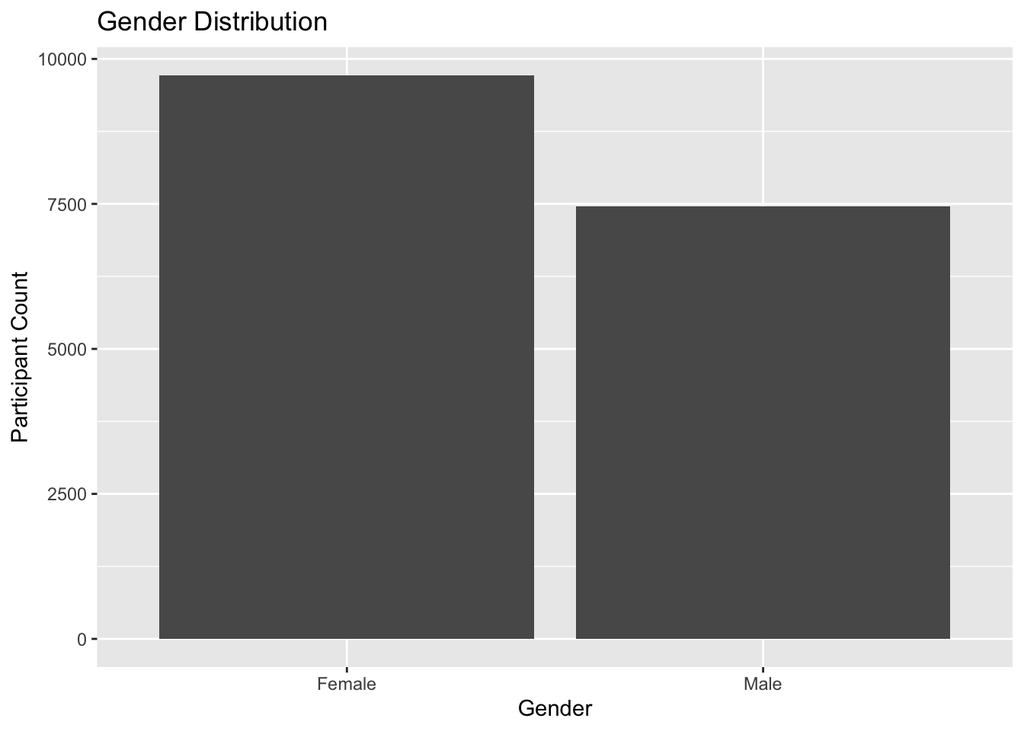

```r
filteredData %>%
  group_by(participant_gender) %>% # Grouping data by participant gender
  summarise(total_participants = sum(participants)) %>% # Sum up the participant counts
  ggplot(aes(x = participant_gender, y = total_participants)) +
  geom_bar(stat = "identity") +
  labs(title = "Gender Distribution", x = "Gender", y = "Participant Count")
```

#### Mobility trends over years

I show how many participants were involved in the international Erasmus program each year. To do this first I have to modify the *mobility_start_month* field because it’s in YYYY-MM format, so with the substring function I get the year data. This can be used to group the data by. As in the previous transformation I summarize the participant counts.

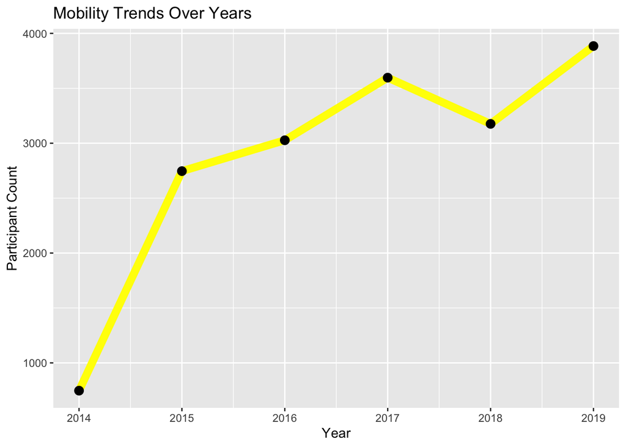

```r
participantsByYearData <- filteredData %>%
  mutate(year = as.numeric(substr(mobility_start_month, 1,4))) %>% # Parse year value from the mobility_start_month
  group_by(year) %>% # Group the data by year
  summarise(total_participants = sum(participants)) # Sum up the participants

ggplot(participantsByYearData, aes(x = year, y = total_participants)) +
  geom_line(color= "yellow", size = 3) +
  geom_point(color= "black", size =3) +
  labs(
    title= "Mobility Trends Over Years",
    x = "Year",
    y = "Participant Count"
  )
```

### Hypothesis testing

My hypothesis is that there is a significant difference in the popularity of Erasmus program between genders. To check my hypothesis I have to transfer the data to see how many participants were in the program by genders. The null hypothesis is that the popularity of Erasmus program is equal between genders. I prepare the data for analysis with grouping by years and genders, to examine the difference in each year, if any.

```r
genderBasedParticipantsByYearData <- filteredData %>%
  mutate(year = as.numeric(substr(mobility_start_month, 1, 4))) %>% # Parse year value
  group_by(year, participant_gender) %>% # Grouping by gender and year of participation
  summarise(total_participants = sum(participants), .groups= "drop") # Count participants

print(genderBasedParticipantsByYearData) # Show the result
```

```
## # A tibble: 12 × 3
##     year participant_gender total_participants
##    <dbl> <fct>                           <dbl>
##  1  2014 Female                            423
##  2  2014 Male                              324
##  3  2015 Female                           1541
##  4  2015 Male                             1205
##  5  2016 Female                           1678
##  6  2016 Male                             1349
##  7  2017 Female                           2015
##  8  2017 Male                             1582
##  9  2018 Female                           1808
## 10  2018 Male                             1368
## 11  2019 Female                           2253
## 12  2019 Male                             1632
```

#### Perform Generalized Lineal Model

I perform a **Poisson regression** with the number of participants as the outcome and participant gender as the predictor. Poisson regression is good for count data and able to model the relationship between a response variable (participants count) and predictors (gender, year).

```r
genderBasedParticipantsByYearData <- genderBasedParticipantsByYearData %>%
  mutate(year = factor(year))

model <- glm(total_participants ~ participant_gender + year, data = genderBasedParticipantsByYearData, family = poisson(link = "log"))
summary(model)
```

```
##
## Call:
## glm(formula = total_participants ~ participant_gender + year,
##     family = poisson(link = "log"), data = genderBasedParticipantsByYearData)
##
## Coefficients:
##                        Estimate Std. Error z value Pr(>|z|)
## (Intercept)             6.04642    0.03719  162.56   <2e-16 ***
## participant_genderMale -0.26442    0.01539  -17.18   <2e-16 ***
## year2015                1.30184    0.04127   31.55   <2e-16 ***
## year2016                1.39926    0.04085   34.25   <2e-16 ***
## year2017                1.57179    0.04021   39.09   <2e-16 ***
## year2018                1.44731    0.04066   35.59   <2e-16 ***
## year2019                1.64881    0.03995   41.27   <2e-16 ***
## ---
## Signif. codes:  0 '***' 0.001 '**' 0.01 '*' 0.05 '.' 0.1 ' ' 1
##
## (Dispersion parameter for poisson family taken to be 1)
##
##     Null deviance: 3076.8278  on 11  degrees of freedom
## Residual deviance:    5.6312  on  5  degrees of freedom
## AIC: 127.4
##
## Number of Fisher Scoring iterations: 3
```

In the result of the model I’m checking the P-value, which tells me if there is statistically significant difference between the genders. Because the P-value is lower than 0.05 it means that it rejects the null hypothesis, so I can conclude that the popularity of the Erasmus program between genders is not equal and it statistically significant and its true for each year. Another way to conclude this result is to see participant_genderMale=-0.26442, this negative value indicates that males on avarage participate less in the Erasmus program, than females which is the reference category in this case. The model also shows that the participants has increased in year by year compared to 2014.

The estimate is 6.04642, which is indicates the estimated count for Female in 2014 is around 422.75, which looks realistic since the real value is 423. The *participant_genderMale* estimate is -0.26442 shows how the male participation is behaves in context of the female participation, so it show males 23.23% less likely to participate in the Erasmus program.

Since the Residual deviance is with value 5.6312 is very low compared to the Null deviance with value 3076.8278, shows a good model fit.

### Statistical Model

#### Check for Overdispersion

To ensure that my Poisson model is correct I checked for overdispersion.

```r
dispersion <- sum(residuals(model, type = "pearson")^2) / model$df.residual
dispersion
```

```
## [1] 1.12526
```

Since dispersion is slightly higher than 1 it means that the poisson model is correct.

#### Q-Q plot (Quantile-Quantile plot)

To check if the residuals follow a specific theoretical distribution. Expectation residuals are normally distributed.

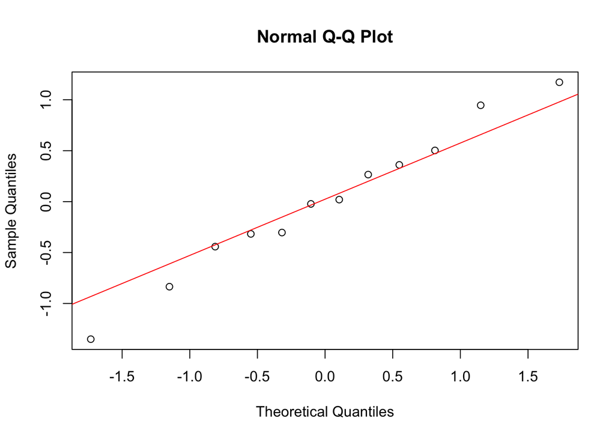

```r
qqnorm(residuals(model, type = "deviance"))
qqline(residuals(model), type = "deviance" , col = "red")
```

The points follows the reference line closely, which indicates the residuals are approximately normal.

#### Residuals vs Fitted Values plot

I expect this model shows that the residuals are randomly placed around zero. So I don’t expect any pattern in the residuals, which can show an incorrect model.

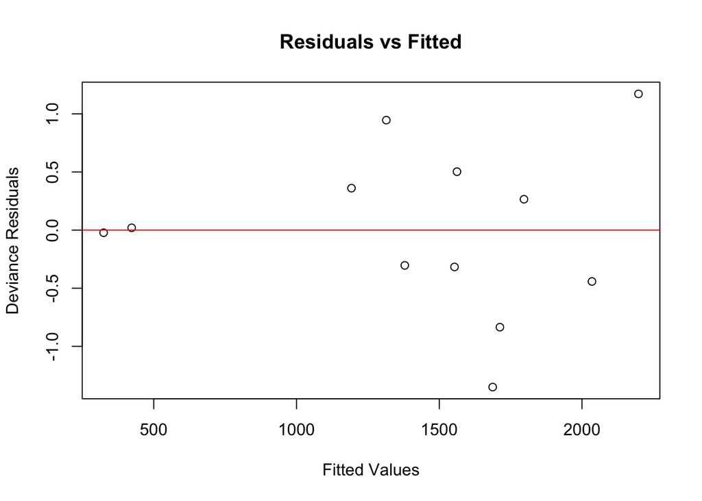

```r
plot(fitted(model), residuals(model, type = "deviance"),
     main = "Residuals vs Fitted", xlab = "Fitted Values", ylab = "Deviance Residuals")
abline(h = 0, col = "red")
```

It shows what i expected.

### Summary

With my analysis I tried to find out if the Erasmus program is more popular in any gender or not, when i check for moving abroad to study cases. I filtered the data and created a few interesting visualization like total gender distribution and popularity of the program year by year. After these steps I defined my hypothesis which was, that there is a significant difference in popularity of the program between genders if I examine the values in each year, so its a trend not just in the summarized values, but over years. My checks proved my hypothesis.